# Fans Matter

Scott C. Ganz and Kieran Allsop

7/7/2021

## Introduction

This is an R Markdown document that replicates the data collection, sorting, and analysis from the working paper [All-star fans and home court advantage](https://www.aei.org/research-products/working-paper/all-star-fans-and-home-court-advantage/) as well as the FiveThirtyEight article [After This Weird NBA Season, We Have A Better Idea Of How Much Fans Matter](https://fivethirtyeight.com/features/after-this-weird-nba-season-we-have-a-better-idea-of-how-much-fans-matter/). The code was originally run on R.4.0.1. Updated versions of R may have been released since this replication file was written.

You will need to install the following packages into R to run this code:

- dplyr
- tidyr
- rvest
- readr
- readxl
- haven
- stringr
- lubridate
- ggplot2
- ggthemes
- ggpubr
- grid
- gridExtra

## Scrape Data

### 2021 Scrape

```r
rawdata <- tibble(date = character(),
                  hometeam = character(),
                  homepts = numeric(),
                  awayteam = character(),
                  awaypts = numeric(),
                  attendance = character(),
                  month = character())

months = c("december", "january", "february", "march", "april", "may")

## Last day of regular season
lastday = as.Date("2021-05-16")

## Scrape data
for (i in 1:length(months)) {
  gamelist <- read_html(str_c("https://www.basketball-reference.com/leagues/NBA_2021_games-", months[i], ".html"))

  x <- gamelist %>% html_element("#schedule") %>% html_table()
  names(x) <- c("date", "time", "awayteam", "awaypts", "hometeam", "homepts", "xx", "yy",
                "attendance", "zz")
  d <- x %>% select(date, hometeam, homepts, awayteam, awaypts, attendance) %>%
    mutate(month = months[i])
  rawdata <- rawdata %>% bind_rows(d)
}

data <- rawdata %>% mutate(attendance = attendance %>% str_replace(",", "") %>% as.numeric,
                           homewin = homepts > awaypts,
                           homemargin = homepts - awaypts)

data <- data %>%
  mutate(date = substring(date, 6),
         date = as.Date(date, format = "%b %d, %Y")) %>%
  filter(date<=lastday)

data <- data %>% group_by(hometeam) %>%
  mutate(gamenumber = 1:n()) %>% ungroup()

## Capacity limits were collected by hand
capacity_lim <- read_excel("../data/stadium_capacity_limits.xlsx", sheet = "long") %>%
  select(-source) %>%
  rename(hometeam=team, pct_allowed = percentage) %>%
  mutate(date = as.Date(date),
         capacity = floor(capacity))

capacity_lim <- capacity_lim %>%
  group_by(hometeam) %>%
  complete(date = seq.Date(min(date), lastday, by="day")) %>%
  fill(stadium, max_capacity, capacity, pct_allowed)

data <- data %>% left_join(capacity_lim) %>%
  filter(!is.na(homepts))
```

```r
## Flag Pacers, Heat, and Kings to be removed fom regression for unreliable attendance data and change games where an
## official attendance was listed on nba.com but basketball reference had 0
data21 <- data %>%
  mutate(attendance = ifelse(hometeam=="Washington Wizards" & date=="2021-05-03", 2133, attendance),
         attendance = ifelse(hometeam=="Portland Trail Blazers" & date=="2021-05-07", 1939, attendance),
         attendance = ifelse(hometeam=="Charlotte Hornets" & date=="2021-03-11", 500, attendance),
         attendance = ifelse(hometeam=="Orlando Magic" & date=="2021-05-05", 4249, attendance),
         attendance = ifelse(hometeam=="Los Angeles Clippers" & date=="2021-02-21", 0, attendance),
         attendance = ifelse(hometeam=="Portland Trail Blazers" & date=="2021-03-23", 0, attendance),
         attendance = ifelse(hometeam=="Golden State Warriors" & date=="2021-02-15", 0, attendance),
         attendance = ifelse(hometeam=="Golden State Warriors" & date=="2021-02-17", 0, attendance),
         attendance = ifelse(hometeam=="Los Angeles Clippers" & date=="2021-02-17", 0, attendance),
         attendance = ifelse(hometeam=="Boston Celtics" & date=="2021-05-02", 0, attendance),
         capacity = ifelse(hometeam=="Minnesota Timberwolves" & date=="2021-04-13", 0, capacity),
         capacity = ifelse(hometeam=="Minnesota Timberwolves" & date=="2021-04-14", 0, capacity),
         capacity = ifelse(hometeam=="Memphis Grizzlies" & date=="2021-02-17", 0, capacity),
         day=weekdays(date))%>%
  mutate(pct_of_cap = attendance/capacity,
         pct_of_max = attendance/max_capacity) %>%
  mutate(reg_remove = ifelse(capacity>0 & attendance==0, 1, 0),
         reg_remove = ifelse(hometeam=="Indiana Pacers" | hometeam=="Miami Heat" | hometeam=="Sacramento Kings", 1, reg_remove))
```

### 2020 Scrape

```r
rawdata20 <- tibble(date = character(),
                  hometeam = character(),
                  homepts = numeric(),
                  awayteam = character(),
                  awaypts = numeric(),
                  attendance = character(),
                  month = character())

months = c("october-2019", "november", "december", "january", "february", "march")

lastday = as.Date("2020-03-10")

for (i in 1:length(months)) {
  gamelist <- read_html(str_c("https://www.basketball-reference.com/leagues/NBA_2020_games-", months[i], ".html"))

  x <- gamelist %>% html_element("#schedule") %>% html_table()
  names(x) <- c("date", "time", "awayteam", "awaypts", "hometeam", "homepts", "xx", "yy",
                "attendance", "zz")
  d <- x %>% select(date, hometeam, homepts, awayteam, awaypts, attendance) %>%
    mutate(month = months[i])
  rawdata <- rawdata %>% bind_rows(d)
}

data <- rawdata %>% mutate(attendance = attendance %>% str_replace(",", "") %>% as.numeric,
                           homewin = homepts > awaypts,
                           homemargin = homepts - awaypts)

data <- data %>%
  mutate(date = substring(date, 6),
         date = as.Date(date, format = "%b %d, %Y"),
         day = weekdays(date)) %>%
  filter(date<=lastday)

## Capacity limits collected by hand from nba.com
capacity_lim<- read_excel("../data/stadium_capacity_limits.xlsx", sheet = "max_cap20") %>%
  rename(hometeam=team)

data <- merge(data, capacity_lim, all.x=T) %>%
  mutate(pct_of_max = attendance/max_capacity, capacity = max_capacity,
         pct_of_cap = attendance/capacity, pct_allowed = 1)

data <- data %>% group_by(hometeam) %>%
  mutate(gamenumber = 1:n()) %>% ungroup()

data20 <- data %>% mutate(reg_remove = 0)
```

### 2016-2019 Scrape

```r
year <- c("15", "16", "17", "18", "19")

rawdata <- list()
data <- list()
## Months of regular season play for all 5 years
months = c("october", "november", "december", "january", "february", "march")

for (i in 1:length(year)){
  rawdata[[year[i]]] <- tibble(date = character(),
                               hometeam = character(),
                               homepts = numeric(),
                               awayteam = character(),
                               awaypts = numeric(),
                               attendance = character(),
                               month = character())

  for (j in 1:length(months)) {
    gamelist <- read_html(str_c("https://www.basketball-reference.com/leagues/NBA_20", year[i],"_games-", months[j], ".html"))

    x <- gamelist %>% html_element("#schedule") %>% html_table()
    names(x) <- c("date", "time", "awayteam", "awaypts", "hometeam", "homepts", "xx", "yy",
                  "attendance", "zz")

    d <- x %>% select(date, hometeam, homepts, awayteam, awaypts, attendance) %>%
      mutate(month = months[j])

    rawdata[[year[i]]] <- rawdata[[year[i]]] %>% bind_rows(d)
  }

  ## Run April separately due to char variable for home and away points in .html file
  gamelist <- read_html(str_c("https://www.basketball-reference.com/leagues/NBA_20", year[i],"_games-april.html"))

  x <- gamelist %>% html_element("#schedule") %>% html_table()
  names(x) <- c("date", "time", "awayteam", "awaypts", "hometeam", "homepts", "xx", "yy",
                "attendance", "zz")
  d <- x %>% select(date, hometeam, homepts, awayteam, awaypts, attendance) %>%
    filter(date!="Playoffs") %>%
    mutate(month = months[i], homepts = as.numeric(homepts), awaypts = as.numeric(awaypts))
  rawdata[[year[i]]] <- rawdata[[year[i]]] %>% bind_rows(d)

  data[[year[i]]] <- rawdata[[year[i]]] %>% mutate(attendance = attendance %>% str_replace(",", "") %>% as.numeric) %>%
    mutate(homewin = homepts > awaypts, homemargin = homepts - awaypts,
           date = substring(date, 6),
           date = as.Date(date, format = "%b %d, %Y"),
           day = weekdays(date))

  ## Capacity limits collected by hand from nba.com.
  capacity_lim<- read_excel("../data/stadium_capacity_limits.xlsx", sheet = str_c("max_cap", year[i])) %>%
    select(-"source") %>%
    rename(hometeam=team)

  data[[year[i]]] <- merge(data[[year[i]]], capacity_lim, all.x=T) %>%
    mutate(pct_of_max = attendance/max_capacity, capacity = max_capacity,
           pct_of_cap = attendance/capacity, pct_allowed = 1)

  data[[year[i]]] <- data[[year[i]]] %>% group_by(hometeam) %>%
    mutate(gamenumber = 1:n()) %>% ungroup()

  data[[year[i]]] <- data[[year[i]]] %>% mutate(reg_remove = 0)
}
```

### Combine Years and Box Scores

```r
## These are dates the playoffs (post season) started. Remove so we only have reg. season
data[["15"]] <- data[["15"]] %>% filter(date<"2015-04-18") %>% mutate(season="2015")
data[["16"]] <- data[["16"]] %>% filter(date<"2016-04-16") %>% mutate(season="2016")
data[["17"]] <- data[["17"]] %>% filter(date<"2017-04-15") %>% mutate(season="2017")
data[["18"]] <- data[["18"]] %>% filter(date<"2018-04-14") %>% mutate(season="2018")
data[["19"]] <- data[["19"]] %>% filter(date<"2019-04-13") %>% mutate(season="2019")
data[["20"]] <- data20 %>% mutate(season="2020")
data[["21"]] <- data21 %>% mutate(season="2021")

DATA_FINAL <- rbind(data[["15"]], data[["16"]])
DATA_FINAL <- rbind(DATA_FINAL, data[["17"]])
DATA_FINAL <- rbind(DATA_FINAL, data[["18"]])
DATA_FINAL <- rbind(DATA_FINAL, data[["19"]])
DATA_FINAL <- rbind(DATA_FINAL, data[["20"]])
DATA_FINAL <- rbind(DATA_FINAL, data[["21"]])

rm(d, gamelist, x, i, j, months, year, capacity_lim, lastday)

## Merge in home and away stats scraped from boxscores in game_scraper.R
away_stats <- read_csv("../data/boxscore_stats_away.csv")
home_stats <- read_csv("../data/boxscore_stats_home.csv")
DATA_FINAL <- merge(DATA_FINAL, home_stats, by=c("hometeam", "date"), all.x = T)
DATA_FINAL <- merge(DATA_FINAL, away_stats, by=c("awayteam", "date"), all.x = T)

DATA_FINAL <- DATA_FINAL %>% group_by(hometeam, season) %>%
  mutate(homeID = cur_group_id()) %>% ungroup()

DATA_FINAL <- DATA_FINAL %>% group_by(awayteam, season) %>%
  mutate(awayID = cur_group_id()) %>% ungroup()

#write_csv(DATA_FINAL, "../data/nba_final_data.csv")
#write_dta(DATA_FINAL, "../data/nba_final_data.dta")
```

## Create Figures

First, read the data back in.

```r
d <- read_csv("../data/nba_final_data.csv") %>%
  mutate(season = as.factor(season))
```

### Figure 1 - Attendance by game histogram 2020-21

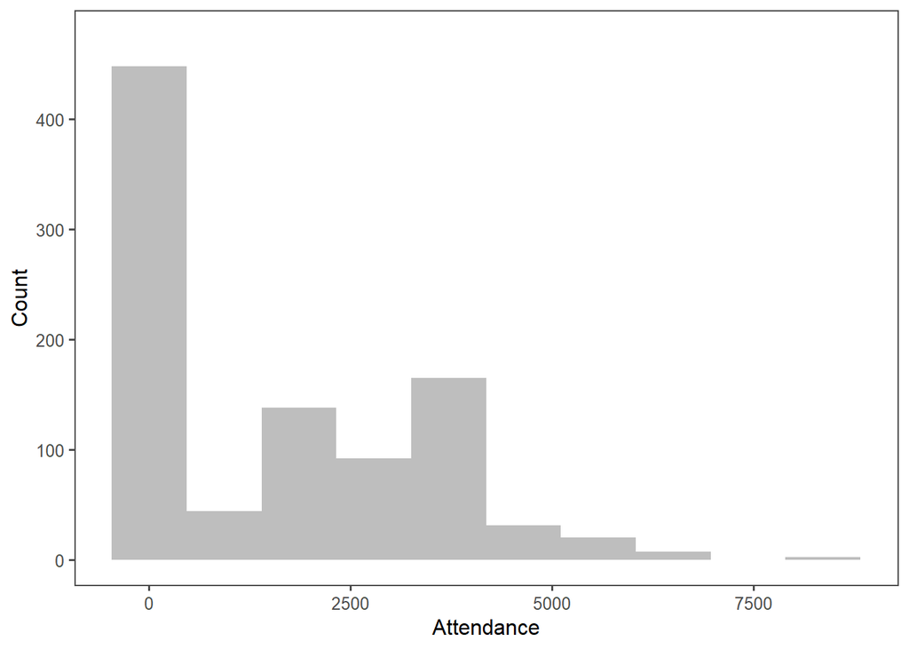

```r
d21 <- d %>% filter(season==2021) %>% filter(reg_remove==0)

attendance_hist <- ggplot(d21, aes(x=attendance)) +
  geom_histogram(fill="gray", bins=10) + theme_few() +
  xlab("Attendance") + ylab("Count") + ylim(0,475)
attendance_hist
```

```r
#ggsave("../graphs/attendance_hist.png")
```

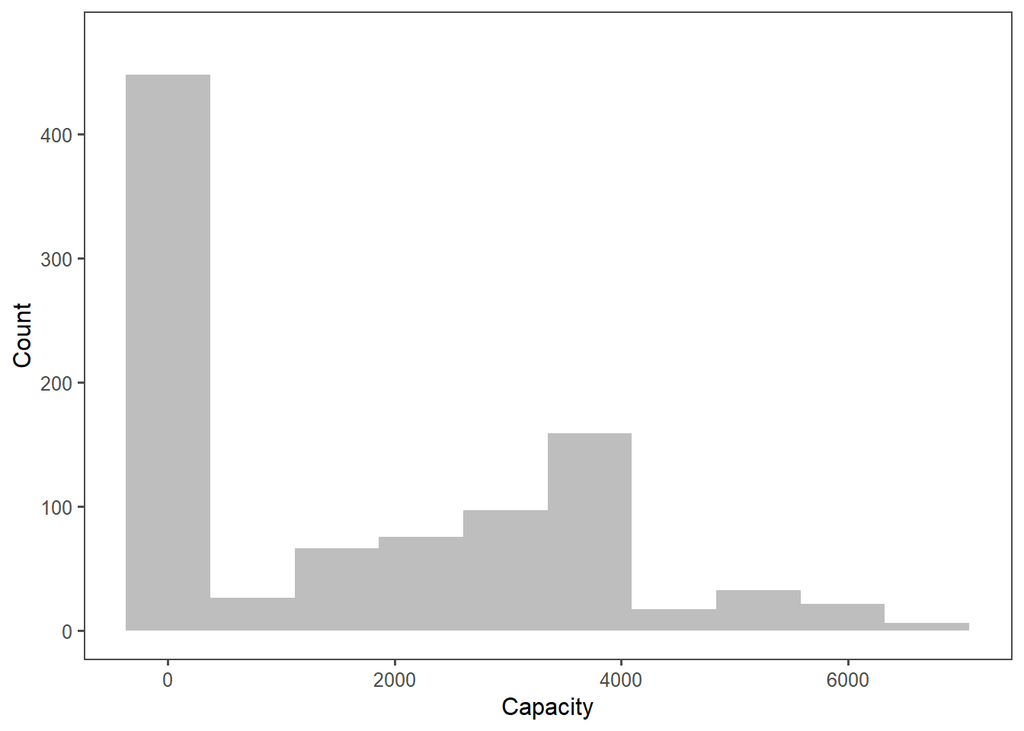

```r
capacity_hist <- ggplot(d21, aes(x=capacity)) +
  geom_histogram(fill="gray", bins=10) + theme_few() +
  xlab("Capacity") + ylab("Count") + ylim(0,475)
capacity_hist
```

```r
#ggsave("../graphs/capacity_hist.png")
```

### Figure 3 - Bivariate relationship (attendance vs capacity)

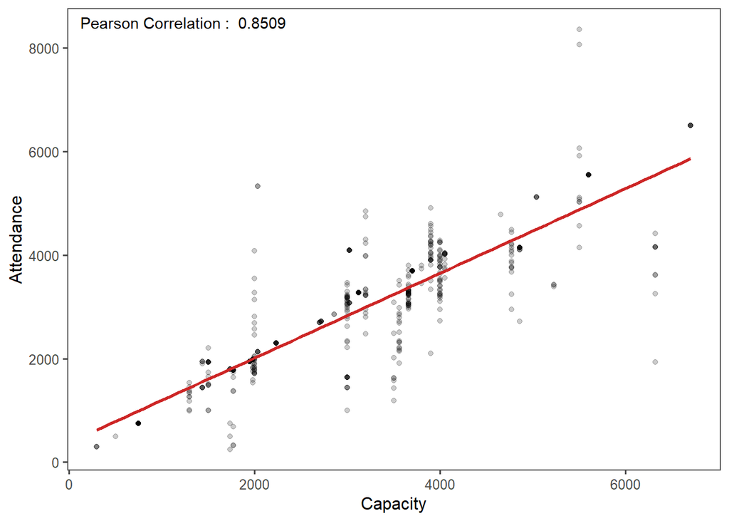

```r
d21corr <- d21 %>% filter(capacity>0) %>% filter(reg_remove==0)
correlation <- cor(d21corr$attendance, d21corr$capacity)

text = grobTree(textGrob(paste("Pearson Correlation : ", round(cor(d21corr$attendance, d21corr$capacity), 4) ),
                          x = 0.02, y = 0.97, hjust = 0, gp = gpar(col = "black", fontsize = 11)))

attendance_corr <- ggplot(d21corr, aes(x=capacity, y=attendance)) +
  geom_point(alpha=1/5) + theme_few() +
  geom_smooth(method='lm', se=F, color="firebrick3") +
  annotation_custom(text) +
  xlab("Capacity") + ylab("Attendance")
attendance_corr
```

```r
#ggsave("../graphs/correlation_minus0s.png")
```

### Figure 4 - Mean Home Margin Across Years

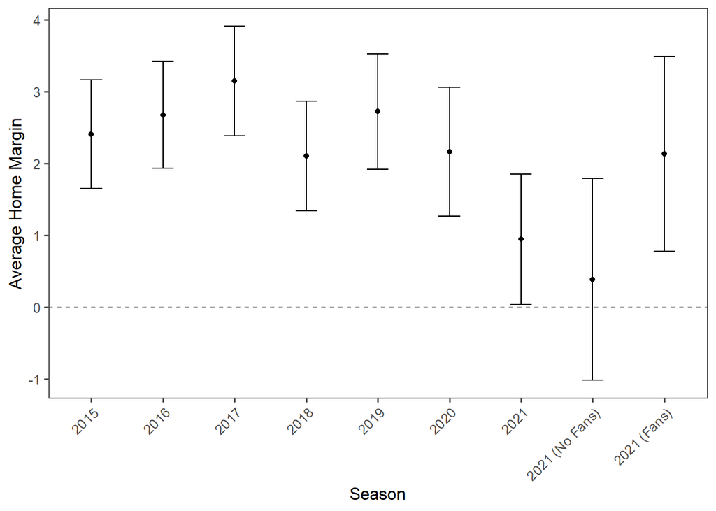

```r
d21_1 <- d %>% filter(season==2021) %>%
  filter(reg_remove==0) %>%
  mutate(season = ifelse(attendance==0, "2021 (No Fans)", "2021 (Fans)"))

means_ext <- rbind(d, d21_1) %>%
  mutate(temp = 1)

means <- means_ext %>%
  group_by(season) %>%
  summarize(homemargin1 = mean(homemargin), sd = sd(homemargin), N = sum(temp)) %>%
  ungroup() %>%
  mutate(se = sd/sqrt(N),
         ci = 1.96*se)


MEANS2 <- ggplot(means, aes(x = season, y = homemargin1)) +
  geom_errorbar(aes(ymin=homemargin1-ci, ymax=homemargin1+ci), width=.3) +
  geom_point(stat="identity") + theme_few() +
  theme(legend.position = "none")+
  ylab("Average Home Margin") + xlab("Season") +
  geom_hline(yintercept = 0, linetype = "dashed", color = "darkgray") +
  theme(axis.text.x = element_text(angle = 45, vjust=1, hjust=1))
MEANS2
```

```r
#ggsave("../graphs/av_homemargin1.png")
```

## Paper and Article Calculations

Paper: “During the 2020-21 regular season, home teams had an average point advantage of $0.94$ points.”

```r
d_a <- d %>% filter(season==2021)
print(str_c("Average home margin in the 2020-21 season = ", round(mean(d_a$homemargin), digits=2)))
```

```
## [1] "Average home margin in the 2020-21 season = 0.94"
```

Paper: “This was substantially lower than the $2.55$-point home court advantage in the prior six seasons.”

```r
d_a <- d %>% filter(season!=2021)
print(str_c("Average home margin in the 2014-15 to 2019-20 seasons = ", round(mean(d_a$homemargin), digits=2)))
```

```
## [1] "Average home margin in the 2014-15 to 2019-20 seasons = 2.55"
```

Paper: “Without fans in attendance [in 2020-21], the home court advantage is $0.39$ points”

FiveThirtyEight Article: “In 440 games played in empty arenas during the regular season, the home team won by 0.39 points”

```r
d_a <- d %>% filter(season==2021 & attendance==0 & reg_remove==0)
print(str_c("Average home margin without fans = ", round(mean(d_a$homemargin), digits=2)))
```

```
## [1] "Average home margin without fans = 0.39"
```

```r
print(str_c("Number of observations = ", nrow(d_a)))
```

```
## [1] "Number of observations = 440"
```

Paper: “With fans in attendance [in 2020-21], in contrast, the home court advantage increases to $2.13$ points”

FiveThirtyEight Article: “In 507 games with fans present, the home court advantage increased to 2.13 points”

```r
d_a <- d %>% filter(season==2021 & attendance>0 & reg_remove==0)
print(str_c("Average home margin with fans = ", round(mean(d_a$homemargin), digits=2)))
```

```
## [1] "Average home margin with fans = 2.13"
```

```r
print(str_c("Number of observations = ", nrow(d_a)))
```

```
## [1] "Number of observations = 507"
```

### Player Comparisons

According to [FiveThirtyEight’s RAPTOR](https://projects.fivethirtyeight.com/nba-player-ratings/), RJ Barrett has an Overall RAPTOR total rating of $0.0$ points per $100$ possessions. Zach LaVine has an overall rating of $+2.3$ points per $100$ possessions. According to the [ESPN 2020-21 Hollinger Team Statistics](http://www.espn.com/nba/hollinger/teamstats/_/sort/paceFactor), the New York Knicks (the team RJ Barrett plays for) average $98.2$ possessions per game and according to [basketball-reference.com](https://www.basketball-reference.com/leagues/NBA_2021_per_game.html), Zach LaVine averaged $35.1$ minutes per game during the 2020-21 season.

```r
a = 2.3 * (98.2/100) * (35.1/48)
print(str_c("According to RAPTOR, Zach LaVine is worth ", round(a, digits=4), " points per game. This is less than the 1.74 difference between playing with and without fans."))
```

```
## [1] "According to RAPTOR, Zach LaVine is worth 1.6516 points per game. This is less than the 1.74 difference between playing with and without fans."
```

According to [FiveThirtyEight’s RAPTOR](https://projects.fivethirtyeight.com/nba-player-ratings/), Luka Doncic has an Overall RAPTOR total rating of $+5.9$ points per $100$ possessions. According to the [ESPN 2020-21 Hollinger Team Statistics](http://www.espn.com/nba/hollinger/teamstats/_/sort/paceFactor), the New York Knicks (the team RJ Barrett plays for) average $98.2$ possessions per game and according to [basketball-reference.com](https://www.basketball-reference.com/leagues/NBA_2021_per_game.html), Luka Doncic averaged $34.3$ minutes per game during the 2020-21 season.

```r
a = 5.9 * (98.2/100) * (34.3/48)
print(str_c("According to RAPTOR, Luka Doncic is worth ", round(a, digits=4), " points per game. This is less than the 4.26 point swing between playing at home with fans compared to playing away with fans."))
```

```
## [1] "According to RAPTOR, Luka Doncic is worth 4.1402 points per game. This is less than the 4.26 point swing between playing at home with fans compared to playing away with fans."
```

## Playoff Data - FiveThirtyEight Article

### Data Scrape and Combine

```r
######################
## 2021 Data Scrape ##
######################

rawdata <- tibble(date = character(),
                  hometeam = character(),
                  homepts = numeric(),
                  awayteam = character(),
                  awaypts = numeric(),
                  attendance = character(),
                  month = character())

months = c("may", "june", "july")
firstday = as.Date("2021-05-22")

## Scrape data
for (i in 1:length(months)) {
  gamelist <- read_html(str_c("https://www.basketball-reference.com/leagues/NBA_2021_games-", months[i], ".html"))

  x <- gamelist %>% html_element("#schedule") %>% html_table()
  names(x) <- c("date", "time", "awayteam", "awaypts", "hometeam", "homepts", "xx", "yy",
                "attendance", "zz")
  d <- x %>% select(date, hometeam, homepts, awayteam, awaypts, attendance) %>%
    mutate(month = months[i])
  rawdata <- rawdata %>% bind_rows(d)
}

data <- rawdata %>% mutate(attendance = attendance %>% str_replace(",", "") %>% as.numeric,
                           homewin = homepts > awaypts,
                           homemargin = homepts - awaypts)

data21 <- data %>%
  mutate(date = substring(date, 6),
         date = as.Date(date, format = "%b %d, %Y"),
         day = weekdays(date)) %>%
  filter(date>=firstday)

###########################
## 2001-2019 Data Scrape ##
###########################

year <- c("01", "02", "03", "04", "05", "06", "07", "08", "09", "10", "11", "12", "13", "14", "15", "16", "17", "18", "19")

rawdata <- list()
data <- list()
months = c("may", "june")

for (i in 1:length(year)){
  rawdata[[year[i]]] <- tibble(date = character(),
                               hometeam = character(),
                               homepts = numeric(),
                               awayteam = character(),
                               awaypts = numeric(),
                               attendance = character(),
                               month = character())

  for (j in 1:length(months)) {
    gamelist <- read_html(str_c("https://www.basketball-reference.com/leagues/NBA_20", year[i],"_games-", months[j], ".html"))

    x <- gamelist %>% html_element("#schedule") %>% html_table()
    names(x) <- c("date", "time", "awayteam", "awaypts", "hometeam", "homepts", "xx", "yy",
                  "attendance", "zz")

    d <- x %>% select(date, hometeam, homepts, awayteam, awaypts, attendance) %>%
      mutate(month = months[j])

    rawdata[[year[i]]] <- rawdata[[year[i]]] %>% bind_rows(d)
  }

  ## Run April separately due to char variable for home and away points in .html file
  gamelist <- read_html(str_c("https://www.basketball-reference.com/leagues/NBA_20", year[i],"_games-april.html"))

  x <- gamelist %>% html_element("#schedule") %>% html_table()
  names(x) <- c("date", "time", "awayteam", "awaypts", "hometeam", "homepts", "xx", "yy",
                "attendance", "zz")
  d <- x %>% select(date, hometeam, homepts, awayteam, awaypts, attendance) %>%
    filter(date!="Playoffs") %>%
    mutate(month = "april", homepts = as.numeric(homepts), awaypts = as.numeric(awaypts))
  rawdata[[year[i]]] <- rawdata[[year[i]]] %>% bind_rows(d)

  data[[year[i]]] <- rawdata[[year[i]]] %>% mutate(attendance = attendance %>% str_replace(",", "") %>% as.numeric) %>%
    mutate(homewin = homepts > awaypts, homemargin = homepts - awaypts,
           date = substring(date, 6),
           date = as.Date(date, format = "%b %d, %Y"),
           day = weekdays(date))
}

#############################
## Keep only Playoff games ##
#############################

data[["01"]] <- data[["01"]] %>% filter(date>="2001-04-21") %>% mutate(season="2001")
data[["02"]] <- data[["02"]] %>% filter(date>="2002-04-20") %>% mutate(season="2002")
data[["03"]] <- data[["03"]] %>% filter(date>="2003-04-19") %>% mutate(season="2003")
data[["04"]] <- data[["04"]] %>% filter(date>="2004-04-17") %>% mutate(season="2004")
data[["05"]] <- data[["05"]] %>% filter(date>="2005-04-23") %>% mutate(season="2005")
data[["06"]] <- data[["06"]] %>% filter(date>="2006-04-22") %>% mutate(season="2006")
data[["07"]] <- data[["07"]] %>% filter(date>="2007-04-21") %>% mutate(season="2007")
data[["08"]] <- data[["08"]] %>% filter(date>="2008-04-19") %>% mutate(season="2008")
data[["09"]] <- data[["09"]] %>% filter(date>="2009-04-18") %>% mutate(season="2009")
data[["10"]] <- data[["10"]] %>% filter(date>="2010-04-17") %>% mutate(season="2010")
data[["11"]] <- data[["11"]] %>% filter(date>="2011-04-16") %>% mutate(season="2011")
data[["12"]] <- data[["12"]] %>% filter(date>="2012-04-28") %>% mutate(season="2012")
data[["13"]] <- data[["13"]] %>% filter(date>="2013-04-20") %>% mutate(season="2013")
data[["14"]] <- data[["14"]] %>% filter(date>="2014-04-19") %>% mutate(season="2014")
data[["15"]] <- data[["15"]] %>% filter(date>="2015-04-18") %>% mutate(season="2015")
data[["16"]] <- data[["16"]] %>% filter(date>="2016-04-16") %>% mutate(season="2016")
data[["17"]] <- data[["17"]] %>% filter(date>="2017-04-15") %>% mutate(season="2017")
data[["18"]] <- data[["18"]] %>% filter(date>="2018-04-14") %>% mutate(season="2018")
data[["19"]] <- data[["19"]] %>% filter(date>="2019-04-13") %>% mutate(season="2019")
data[["21"]] <- data21 %>% filter(date>="2021-05-22") %>% mutate(season="2021")

year <- append(year, "21")

###############################
## Collect in one data frame ##
###############################

DATA_FINAL <- rbind(data[["01"]], data[["02"]])
for (i in 3:length(year)){
  DATA_FINAL <- rbind(DATA_FINAL, data[[year[i]]])

}

DATA_FINAL <- DATA_FINAL %>%
  filter(date<"2021-06-29")
rm(firstday, i, j, months, rawdata, d, data21, gamelist, x)
```

### Mean home win margins

```r
means <- tibble()

for (i in 1:length(year)) {
  a <- DATA_FINAL %>% filter(season==str_c("20",year[i]))
  x <- mean(a$homemargin)
  x1 <- mean(a$homewin)
  y <- tibble(year = year[i], homemargin = x, homewin = x1)

  means <- rbind(means, y)
}

means <- means %>% mutate(year=as.numeric(year), year = year + 2000)
rm(i, x, x1, y, a)
means
```

```
## # A tibble: 20 x 3
##     year homemargin homewin
##    <dbl>      <dbl>   <dbl>
##  1  2001       2.97   0.577
##  2  2002       2.92   0.592
##  3  2003       3.61   0.614
##  4  2004       6.60   0.720
##  5  2005       4.19   0.560
##  6  2006       4.75   0.674
##  7  2007       4.81   0.658
##  8  2008       8.08   0.744
##  9  2009       4.11   0.671
## 10  2010       4.5    0.671
## 11  2011       3.64   0.667
## 12  2012       4.68   0.679
## 13  2013       4      0.635
## 14  2014       2.84   0.562
## 15  2015       2.14   0.593
## 16  2016       8.07   0.674
## 17  2017       2.06   0.570
## 18  2018       6.28   0.707
## 19  2019       3.82   0.561
## 20  2021       3.16   0.547
```

```r
print(str_c("There have been ", nrow(data[["21"]])," games so far in the post-season (as of 6/30/2021). Those games have had an average home margin of ", round(means$homemargin[means$year==2021], digits=2), "."))
```

```
## [1] "There have been 85 games so far in the post-season (as of 6/30/2021). Those games have had an average home margin of 3.16."
```

```r
print(str_c("The average margins in the following 10, non-bubble, playoffs are as follows: ", round(means$homemargin[means$year==2019], digits=2), ", ", round(means$homemargin[means$year==2018], digits=2), ", ", round(means$homemargin[means$year==2017], digits=2), ", ", round(means$homemargin[means$year==2016], digits=2), ", ", round(means$homemargin[means$year==2015], digits=2), ", ", round(means$homemargin[means$year==2014], digits=2), ", ", round(means$homemargin[means$year==2013], digits=2), ", ", round(means$homemargin[means$year==2012], digits=2), ", ", round(means$homemargin[means$year==2011], digits=2), ", ", round(means$homemargin[means$year==2010], digits=2), "."))
```

```
## [1] "The average margins in the following 10, non-bubble, playoffs are as follows: 3.82, 6.28, 2.06, 8.07, 2.14, 2.84, 4, 4.68, 3.64, 4.5."
```